# 1. 安装 Python 版本

① 首先打开 Anaconda 的 Prompt 终端，输入 jupyter kernelspec list，查看已经安装的 python 版本。如下图所示，只有 Anaconda 自带的 python3。

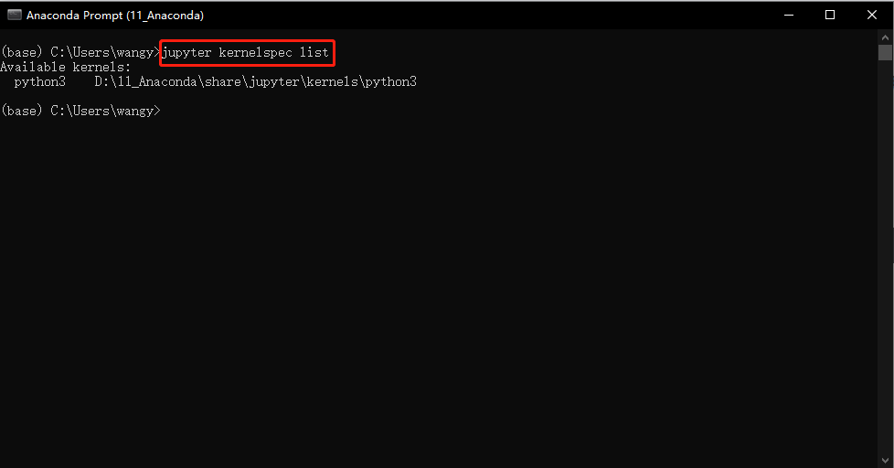

② 输入 conda create --name py3.6.3 python=3.6.3 命令，输入 [y]/n 时输入 y，创建 py3.6.3 虚拟环境，它会安装 python3.6.3 到 anaconda3 的 env 目录下。

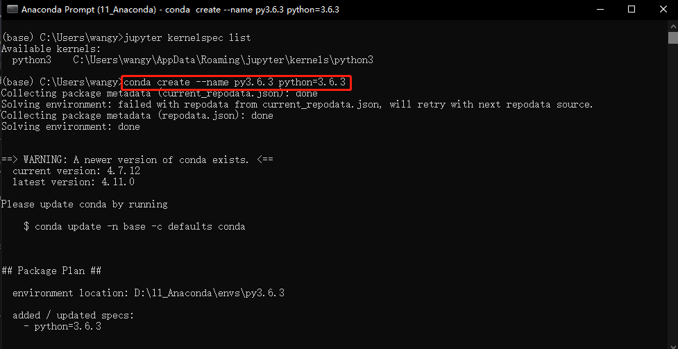

[figure not shown]

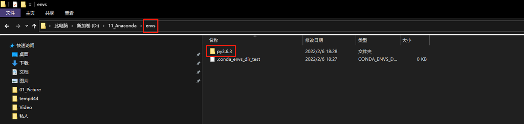

③ 首先确保目前盘和要进入的盘一样，输入 cd D:\11_Anaconda\envs\py3.6.3\Scripts 命令，进入 py3.6.3 目录下的 Scripts 文件夹下。

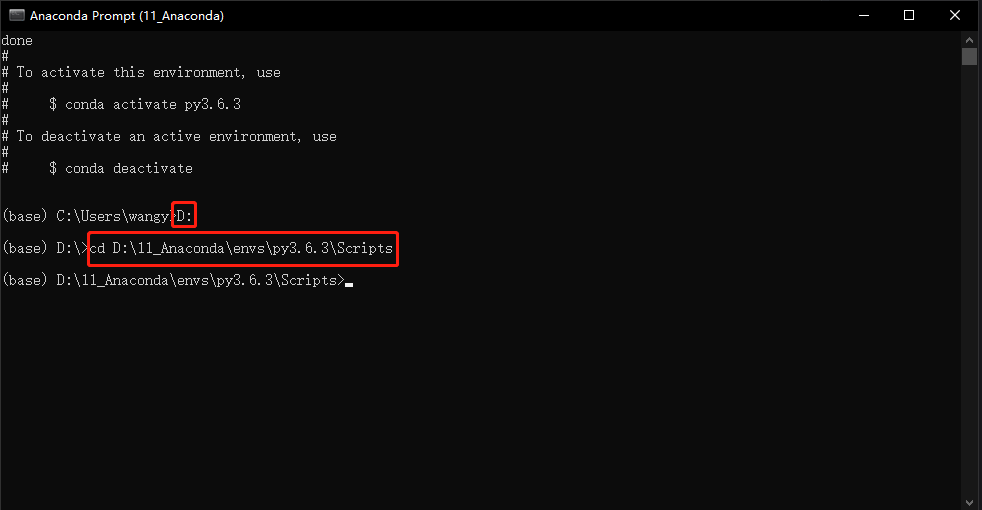

④ 输入 conda activate py3.6.3 激活 py3.6.3环境后，再输入 pip install ipykernel 命令，会在 script 目录下会生成一系列工具，如下图所示。( 注意：当 pip install ipykernel 时，不能挂 VNP。)

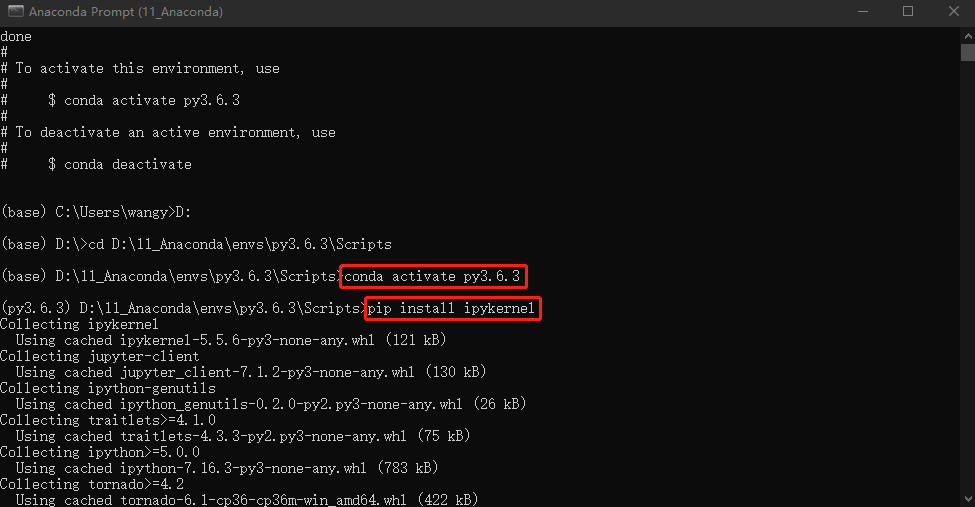

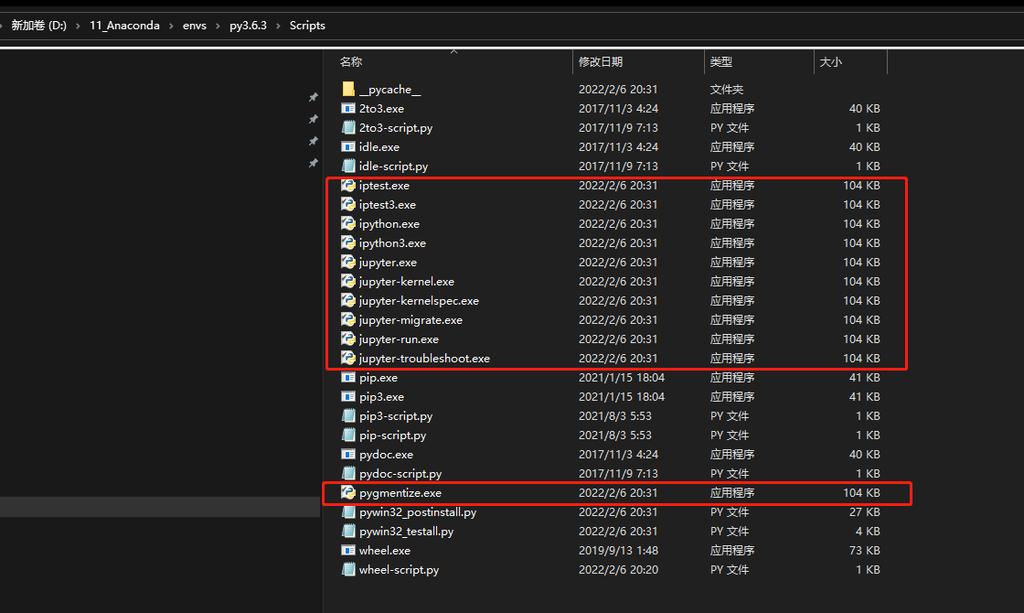

⑤ 将 Anaconda 文件夹下的 share/jupyter/kernels 文件夹中已经存在的项目复制一份，重命名为 python3.6.3。

[figure not shown]

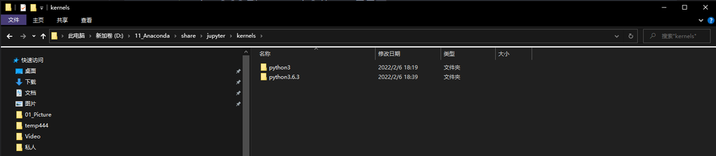

⑥ 打开文件夹中 json 文件，将 Python 3 改为 Python 3.6.3，如下图所示。

[figure not shown]

[figure not shown]

⑦ 再次打开 Anaconda 终端，输入 jupyter kernelspec list，可以查看到已成功安上 Python3.6.3 的虚拟环境。

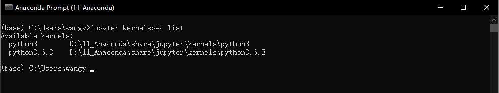

⑧ 再次打开 Jupyter notebook，New 里面有 Python3.6.3 选项。

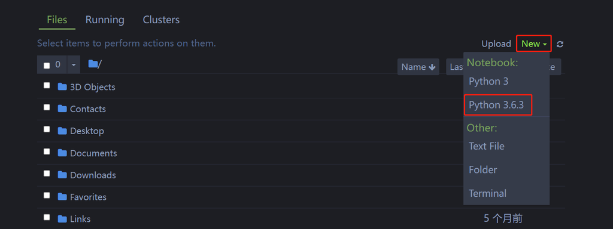

⑨ 在 Jupyter notebook 中，用 python 代码打印 python 版本。

```python
import sys
print(sys.version)
```

```
3.6.3 |Anaconda, Inc.| (default, Nov  8 2017, 15:10:56) [MSC v.1900 64 bit (AMD64)]
```

# 2. 安装 d2l 库

① 既可以在jupyter notebook中输入 "pip install d2l" 安装d2l，也可以在Anaconda Prompt终端中输入 "pip install d2l" 安装d2l。

② 如果安装速度过慢，或安装不成功，尝试一下添加镜像源。

```python
pip install d2l
```

```python
import d2l
from d2l import torch as d2l
```